# M7 Data Analysis - Nonparametrics

Benjamin Panny

11/9/2021

# 1 Part 1: CDAI and Treatment with Biologics

## 1.1 Numerical and Visual Summary

```r
kableExtra::kable(summarize(ra, CDAI_nNA = sum(is.na(cdai)), mean = mean(cdai, na.rm = TRUE), SD = sd(cdai,
    na.rm = TRUE), median = median(cdai, na.rm = TRUE), IQR = quantile(cdai, 0.75, na.rm = TRUE) - quantile(cdai,
    0.25, na.rm = TRUE), min = min(cdai, na.rm = TRUE), max = max(cdai, na.rm = TRUE)), digits = 3, "simple",
    caption = "Table 1: Numerical summary of CDAI (arbitrary units (>10 and <23 indicates moderate disease activity))")
```

Table 1: Numerical summary of CDAI (arbitrary units (>10 and <23 indicates moderate disease activity))

| CDAI_nNA | mean | SD | median | IQR | min | max |
| --- | --- | --- | --- | --- | --- | --- |
| 324 | 13.097 | 11.06 | 10 | 11 | 0 | 71 |

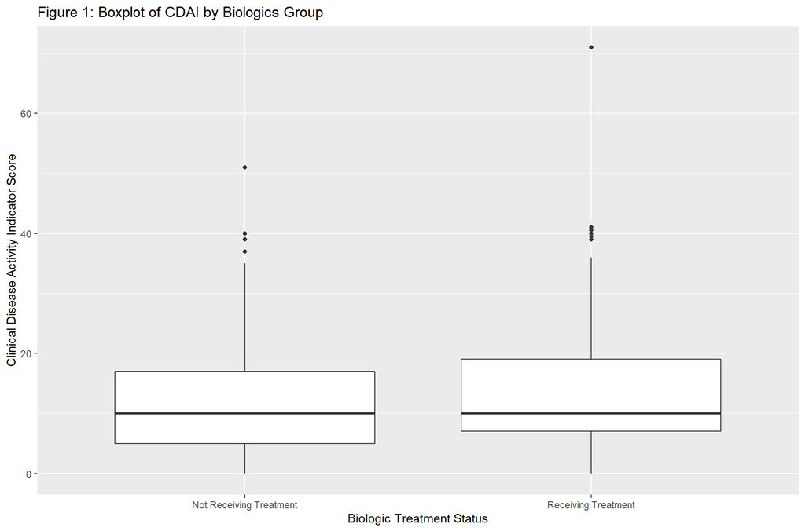

```r
f <- ggplot(ra %>% drop_na(Biologics), aes(x = Biologics, y = cdai, na.rm = TRUE))


f + geom_boxplot() + xlab("Biologic Treatment Status") + ylab("Clinical Disease Activity Indicator Score") +
    ggtitle("Figure 1: Boxplot of CDAI by Biologics Group")
```

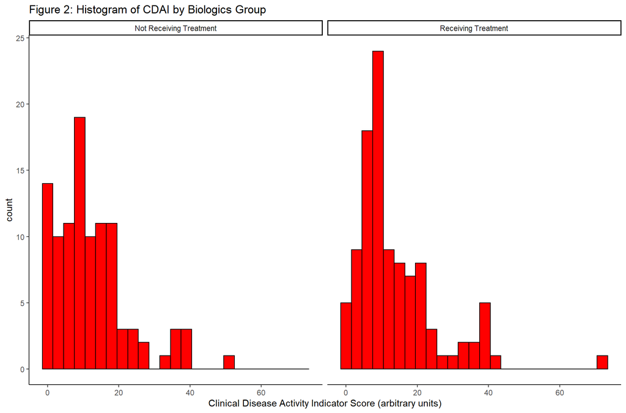

```r
ggplot(ra %>% drop_na(Biologics, cdai), aes(x = cdai)) + geom_histogram(binwidth = 3, fill = "red", color = "black") +
    facet_wrap(~Biologics) + theme_classic() + xlab("Clinical Disease Activity Indicator Score (arbitrary units)") +
    ggtitle("Figure 2: Histogram of CDAI by Biologics Group")
```

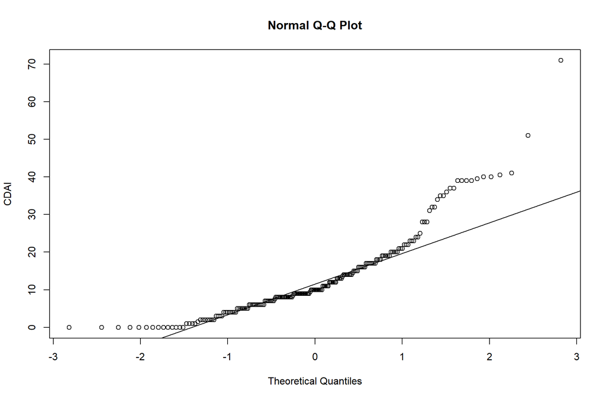

```r
qqnorm(ra$cdai, ylab = "CDAI")
qqline(ra$cdai)
```

## 1.2 Null and Alternative Hypotheses

The null hypothesis is that the population median from the group without biologics is the same as the population median from the group with biologics.

The alternative hypothesis is that the population median from the group without biologics is different than the population median from the group with biologics.

## 1.3 Conditions for a Wilcoxon rank sum test

Two independent random samples: we will assume the participants in each sample (biologic or no biologic) are independent Population Distributions have the same shape: As can be seen in Figure 2, the sample distributions are roughly the same shape and we will assume the populations are similar as well.

## 1.4 Wilcoxon Rank-Sum Test and P-value with Interpretation

```r
wilcox.test(ra$cdai ~ ra$Biologics)
```

```
##
##  Wilcoxon rank sum test with continuity correction
##
## data:  ra$cdai by ra$Biologics
## W = 4830.5, p-value = 0.2684
## alternative hypothesis: true location shift is not equal to 0
```

## 1.5 Statistical Decision and Conclusion with Potential for Alternative Test

Due to a statistically insignificant p-value (p =.268 > .05), we fail to reject the null hypothesis that the population median of the group without biologics is the same as the population median of the group with biologics. We have no evidence to suggest that the population median of the group without biologics is different from the population median of the group with biologics. Therefore, we have no evidence to suggest an association between biologics and clinical disease activity indicator score.

We could have used a two-sample t-test here to test for a difference in the average CDAI score between treatment groups. That is, the samples are random and independent, and they are also large enough (each greater than 30) to use in spite of not being normally distributed outside of the first standard deviation (they are right skewed).

# 2 Part 2. Age and CDAI

## 2.1 Numerical and Visual Summary

```r
tbl <- table(ra$AgeGp, ra$CDAI_YN)
rownames(tbl) <- c("40-70 Years Old", "75+ Years Old")
kableExtra::kable(tbl, digits = 3, "simple", caption = "Table 2: Number of Patients with CDAI Measured By Age Group")
```

Table 2: Number of Patients with CDAI Measured By Age Group

|  | CDAI measured | CDAI not measured |
| --- | --- | --- |
| 40-70 Years Old | 193 | 266 |
| 75+ Years Old | 13 | 58 |

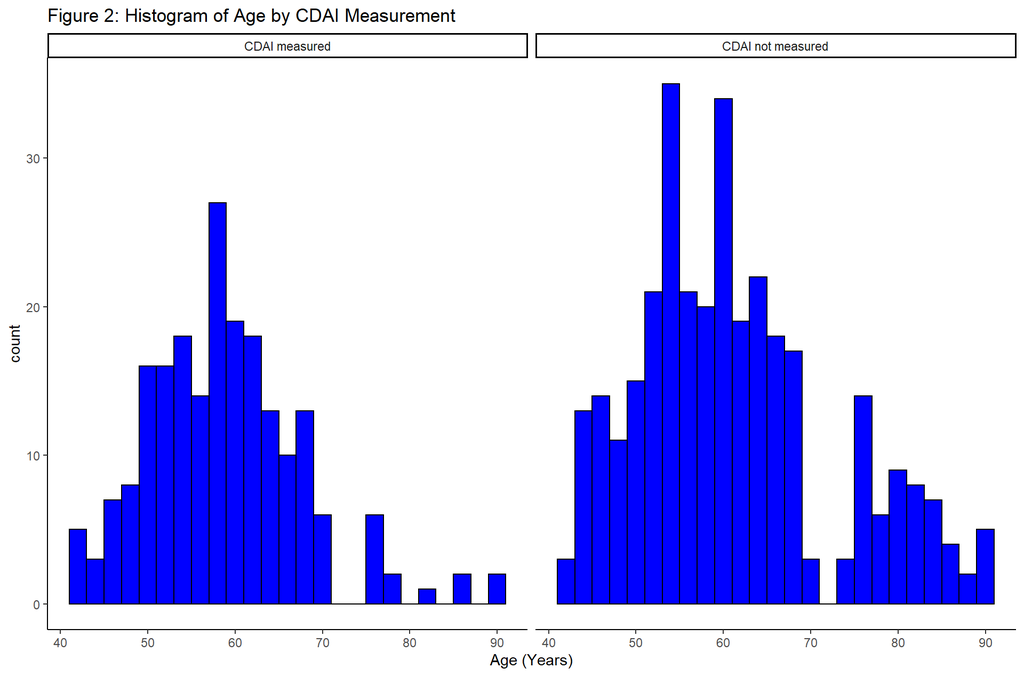

```r
ggplot(ra %>% drop_na(CDAI_YN, Age), aes(x = Age)) + geom_histogram(binwidth = 2, fill = "blue", color = "black") +
    facet_wrap(~CDAI_YN) + theme_classic() + xlab("Age (Years)") + ggtitle("Figure 2: Histogram of Age by CDAI Measurement")
```

## 2.2 Null and Alternative Hypotheses

The null hypothesis is that CDAI measurement is not associated with age group.

The alternative hypothesis is that CDAI measurement is associated with age group.

## 2.3 Conditions for Fisher’s Exact Test

Simple random sample: we will assume the participants in our sample are randomly selected.

## 2.4 P-value with Interpretation and Statistical Decision.

There is no test statistic for a Fisher’s exact test. The p-value is roughly 0.00012. This indicates a 0.012% chance of observing the counts we observe if CDAI measurement is not associated with age group. Due to a statistically significant p-value (p <.001), we reject the null hypothesis CDAI measurement is not associated with age group.

```r
m <- matrix(c(193, 13, 266, 58), nrow = 2)
fisher.test(m)
```

```
##
##  Fisher's Exact Test for Count Data
##
## data:  m
## p-value = 0.0001205
## alternative hypothesis: true odds ratio is not equal to 1
## 95 percent confidence interval:
##  1.690724 6.616063
## sample estimates:
## odds ratio
##   3.230571
```

## 2.5 Conclusion with Potential for chi-squared test

We have very strong evidence to suggest that CDAI measurement is associated with age group. The odds ratio is 3.23, indicating the likelihood of having CDAI measured in the 40-70 years old group is 3.23 times more likely than in the 75+ years old group.

We could have used a chi square test of independence. Since the hypotheses regarding association are the same and the expected cell counts are greater than 5.

# 3 Part 3. Age and Treatment with Biologics

## 3.1 Numerical and Visual Summary

```r
tbl <- table(ra$AgeGp, ra$Biologics)
rownames(tbl) <- c("40-70 Years Old", "75+ Years Old")
kableExtra::kable(tbl, digits = 3, "simple", caption = "Table 3: Number of Patients with Biologic Treatment By Age Group")
```

Table 3: Number of Patients with Biologic Treatment By Age Group

|  | Not Receiving Treatment | Receiving Treatment |
| --- | --- | --- |
| 40-70 Years Old | 272 | 187 |
| 75+ Years Old | 60 | 10 |

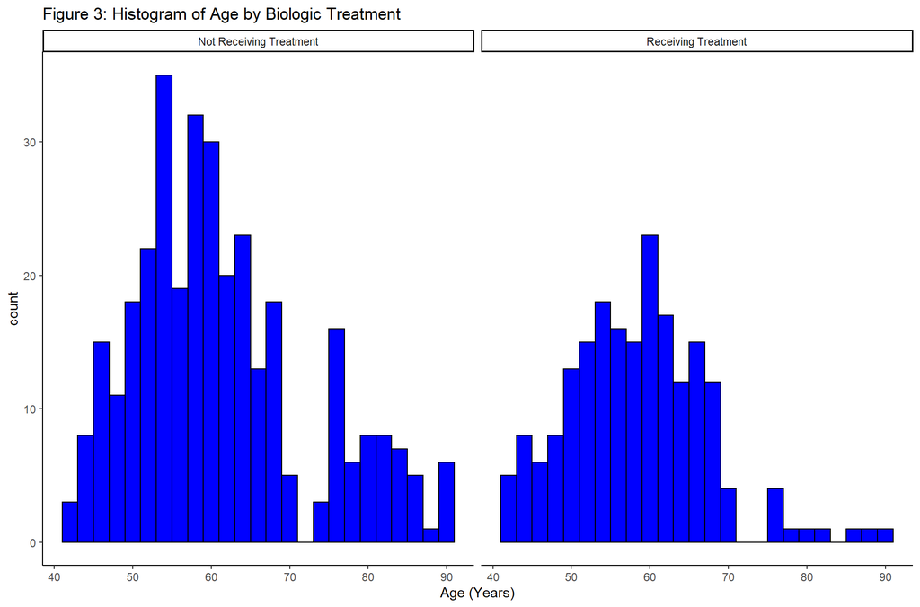

```r
ggplot(ra %>% drop_na(Biologics, Age), aes(x = Age)) + geom_histogram(binwidth = 2, fill = "blue", color = "black") +
    facet_wrap(~Biologics) + theme_classic() + xlab("Age (Years)") + ggtitle("Figure 3: Histogram of Age by Biologic Treatment")
```

## 3.2 Null and Alternative Hypotheses

The null hypothesis is that biologics treatment status is not associated with age group.

The alternative hypothesis is that biologics treatment status is associated with age group.

## 3.3 Conditions for Fisher’s Exact Test

Simple random sample: we will assume the participants in our sample are randomly selected.

## 3.4 P-value with Interpretation and Statistical Decision.

There is no test statistic for a Fisher’s exact test. The p-value is roughly 0.0000089. This indicates a 0.00089% chance of observing the counts we observe if biologics treatment status is not associated with age group. Due to a statistically significant p-value (p <.001), we reject the null hypothesis that biologics treatment status is not associated with age group.

```r
m <- matrix(c(272, 60, 187, 10), nrow = 2)
fisher.test(m)
```

```
##
##  Fisher's Exact Test for Count Data
##
## data:  m
## p-value = 8.891e-06
## alternative hypothesis: true odds ratio is not equal to 1
## 95 percent confidence interval:
##  0.1080309 0.4940959
## sample estimates:
## odds ratio
##   0.242972
```

## 3.5 Conclusion with Potential for chi-squared test

We could have used a chi square test of independence. Since the hypotheses regarding association are the same and the expected cell counts are greater than 5.

# 4 Part 4: Comment on Missing Data